# EPID 600 Project Template

## Overlap of DE genes between DESeq2 and Cuffdiff For Crispr gene

```r
Query_Cuffdiff_Sig <- read.xlsx("C:/Users/malmwamu/Documents/Epid600/Epid600-project/QueryGene-cuffdiff/QueryGene-Wild-Mutants-Signicant-Diff-Genes.xlsx", 1)
Query_Cuffdiff <- read.csv("C:/Users/malmwamu/Documents/Epid600/Epid600-project/QueryGene-cuffdiff/QueryGene-all-genes-cuffquant-firststrand.csv", header = TRUE, sep = ",")
Query_DESeq2_Sig<- read.xlsx("C:/Users/malmwamu/Documents/Epid600/Epid600-project/QueryGene/GeneInterestSig-DESeq2.xlsx", 1)
Query_DESeq2 <- read.csv("C:/Users/malmwamu/Documents/Epid600/Epid600-project/QueryGene/geneInterest-Allgenes-results-DESeq2.csv", header = TRUE, sep = ",")

str(Query_DESeq2_Sig)
```

```
## 'data.frame':    415 obs. of  7 variables:
##  $ GeneID        : Factor w/ 415 levels "ENSG00000003436.10",..: 29 258 46 254 232 171 366 41 112 352 ...
##  $ baseMean      : num  1459 1061 580 626 315 ...
##  $ log2FoldChange: num  -6.3 -6.68 -5.95 -4.97 -5.38 ...
##  $ lfcSE         : num  0.336 0.36 0.38 0.357 0.404 ...
##  $ stat          : num  -18.8 -18.5 -15.7 -13.9 -13.3 ...
##  $ pvalue        : num  1.17e-78 1.01e-76 2.06e-55 3.55e-44 1.69e-40 ...
##  $ padj          : num  2.19e-74 9.49e-73 1.28e-51 1.66e-40 6.32e-37 ...
```

```r
str(Query_Cuffdiff_Sig)
```

```
## 'data.frame':    102 obs. of  14 variables:
##  $ GeneID     : Factor w/ 102 levels "ENSG00000025708.8",..: 1 2 3 4 5 6 7 8 9 10 ...
##  $ gene_id    : Factor w/ 102 levels "ENSG00000025708.8",..: 1 2 3 4 5 6 7 8 9 10 ...
##  $ gene       : Factor w/ 102 levels "42250","ABCA1",..: 99 93 34 88 39 96 1 5 43 56 ...
##  $ locus      : Factor w/ 101 levels "1:145438468-145442635",..: 49 76 52 73 100 9 48 47 36 99 ...
##  $ sample_1   : Factor w/ 1 level "Wild": 1 1 1 1 1 1 1 1 1 1 ...
##  $ sample_2   : Factor w/ 1 level "Mutant": 1 1 1 1 1 1 1 1 1 1 ...
##  $ status     : Factor w/ 1 level "OK": 1 1 1 1 1 1 1 1 1 1 ...
##  $ value_1    : num  0.2544 0.5551 6.5957 0.0744 4.9734 ...
##  $ value_2    : num  0 0.000288 0.030965 1.16032 1.00997 ...
##  $ log2FC     : Factor w/ 69 levels "-1.34008","-1.4138",..: NA 8 30 68 10 25 67 63 49 64 ...
##  $ test_stat  : num  NA -0.0168 -2.5282 2.1795 -2.9612 ...
##  $ p_value    : num  2e-04 5e-05 1e-04 2e-04 2e-04 5e-05 5e-05 5e-05 5e-05 5e-05 ...
##  $ q_value    : num  0.0402 0.014 0.0241 0.0402 0.0402 ...
##  $ significant: Factor w/ 1 level "yes": 1 1 1 1 1 1 1 1 1 1 ...
```

```r
str(Query_DESeq2)
```

```
## 'data.frame':    30585 obs. of  7 variables:
##  $ GeneID        : Factor w/ 30585 levels "ENSG00000000003.10",..: 1033 9964 1833 9876 9296 6578 17029 1484 4528 15347 ...
##  $ baseMean      : num  1459 1061 580 626 315 ...
##  $ log2FoldChange: num  -6.3 -6.68 -5.95 -4.97 -5.38 ...
##  $ lfcSE         : num  0.336 0.36 0.38 0.357 0.404 ...
##  $ stat          : num  -18.8 -18.5 -15.7 -13.9 -13.3 ...
##  $ pvalue        : num  1.17e-78 1.01e-76 2.06e-55 3.55e-44 1.69e-40 ...
##  $ padj          : num  2.19e-74 9.49e-73 1.28e-51 1.66e-40 6.32e-37 ...
```

```r
str(Query_Cuffdiff)
```

```
## 'data.frame':    57815 obs. of  14 variables:
##  $ GeneID           : Factor w/ 57815 levels "ENSG00000000003.10",..: 1 2 3 4 5 6 7 8 9 10 ...
##  $ gene_id          : Factor w/ 57815 levels "ENSG00000000003.10",..: 1 2 3 4 5 6 7 8 9 10 ...
##  $ gene             : Factor w/ 55758 levels "1-Dec","1-Mar",..: 53163 52455 13864 48754 8263 15628 9697 15965 16256 25078 ...
##  $ locus            : Factor w/ 34053 levels "1:100111498-100160097",..: 33616 33615 18954 1135 1135 2318 1443 25797 26853 26651 ...
##  $ sample_1         : Factor w/ 1 level "Wild": 1 1 1 1 1 1 1 1 1 1 ...
##  $ sample_2         : Factor w/ 1 level "Mutant": 1 1 1 1 1 1 1 1 1 1 ...
##  $ status           : Factor w/ 3 levels "FAIL","NOTEST",..: 3 2 3 3 3 2 2 3 3 3 ...
##  $ value_1          : num  49.48 0 70.21 9.02 13.39 ...
##  $ value_2          : num  37.106 0.00101 50.9629 6.4707 11.2972 ...
##  $ log2.fold_change.: Factor w/ 27431 levels "-0.000248434",..: 6390 27431 7097 7323 3732 27431 14751 1880 2169 6487 ...
##  $ test_stat        : Factor w/ 18960 levels "-0.000101662",..: 9355 11828 6852 6486 3987 11828 11828 3863 3066 7471 ...
##  $ p_value          : num  0.272 1 0.519 0.551 0.721 ...
##  $ q_value          : num  0.999 1 0.999 0.999 0.999 ...
##  $ significant      : Factor w/ 2 levels "no","yes": 1 1 1 1 1 1 1 1 1 1 ...
```

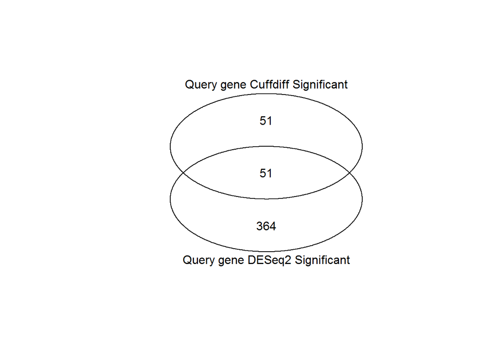

```r
Query_DESeq2$GeneID <- as.character(Query_DESeq2[["GeneID"]])
Query_Cuffdiff$GeneID <- as.character(Query_Cuffdiff[["GeneID"]])
Query_DESeq2_Sig$GeneID <- as.character(Query_DESeq2_Sig[["GeneID"]])
Query_Cuffdiff_Sig$GeneID <- as.character(Query_Cuffdiff_Sig[["GeneID"]])

# Common DE between Crispr gene DESeq2 and Cuffdiff
venn(list("Query gene DESeq2 Significant" = Query_DESeq2_Sig$GeneID, "Query gene Cuffdiff Significant" = Query_Cuffdiff_Sig$GeneID))
```

```r
#There were 51 genes that were commonly differentially expressed between cuffdiff and DESEq2 in crispr gene

#extract total genes (Significant and non significant) that are common between cuffdiff and DESeq2 for crispr samples
commonCrispr_All_DESEq2_Cuffdiff <- Query_DESeq2[Query_DESeq2$GeneID %in% Query_Cuffdiff$GeneID,]
commonCrispr_All_Cuffdiff_DESeq2 <- Query_Cuffdiff[Query_Cuffdiff$GeneID %in% Query_DESeq2$GeneID,]

#Merge to keep only the  total genes present in both cuffdiff and DESeq2 and also be able to obtain gene symbols via cuffdiff results
Crispr_cuffDes <- merge(commonCrispr_All_Cuffdiff_DESeq2[,c(1,3,10,13)], commonCrispr_All_DESEq2_Cuffdiff[,c(1,3,7)])

#Remove NAs from merged dataframe and rename columns
Crispr_cuffDes <- Crispr_cuffDes[complete.cases(Crispr_cuffDes),]
Crispr_cuffDes <- rename(Crispr_cuffDes, c("q_value" = "Cuffdiff_adjp", "padj" = "DESeq2_adjp"))
Crispr_cuffDes <- rename(Crispr_cuffDes, c("log2.fold_change." = "log2FC_Cuffdiff", "log2FoldChange" = "log2FC_DESeq2"))

#correlation coefficient, linear model fit and confident interval of fit.
cor(Crispr_cuffDes$Cuffdiff_adjp, Crispr_cuffDes$DESeq2_adjp, use = "complete.obs")
```

```
## [1] 0.5288554
```

```r
fitCrispr <- lm(Cuffdiff_adjp ~ DESeq2_adjp, data=Crispr_cuffDes)
fitCrispr
```

```
##
## Call:
## lm(formula = Cuffdiff_adjp ~ DESeq2_adjp, data = Crispr_cuffDes)
##
## Coefficients:
## (Intercept)  DESeq2_adjp
##      0.7341       0.2826
```

```r
confint(fitCrispr)
```

```
##                 2.5 %    97.5 %
## (Intercept) 0.7283968 0.7397445
## DESeq2_adjp 0.2761049 0.2890981
```

```r
summary(fitCrispr)
```

```
##
## Call:
## lm(formula = Cuffdiff_adjp ~ DESeq2_adjp, data = Crispr_cuffDes)
##
## Residuals:
##      Min       1Q   Median       3Q      Max
## -1.00075 -0.01535 -0.00649  0.02350  0.26532
##
## Coefficients:
##             Estimate Std. Error t value Pr(>|t|)
## (Intercept) 0.734071   0.002895  253.59   <2e-16 ***
## DESeq2_adjp 0.282601   0.003314   85.26   <2e-16 ***
## ---
## Signif. codes:  0 '***' 0.001 '**' 0.01 '*' 0.05 '.' 0.1 ' ' 1
##
## Residual standard error: 0.1061 on 18723 degrees of freedom
## Multiple R-squared:  0.2797, Adjusted R-squared:  0.2796
## F-statistic:  7270 on 1 and 18723 DF,  p-value: < 2.2e-16
```

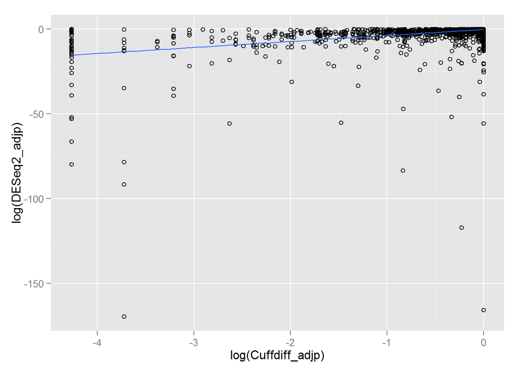

```r
#log plot of cuffdiff adjusted P versus DESeq2 adjusted P
ggplot(data = Crispr_cuffDes, aes(x = log(Cuffdiff_adjp), y = log(DESeq2_adjp))) + geom_point(shape = 21) + geom_smooth(method=lm, se=FALSE)
```

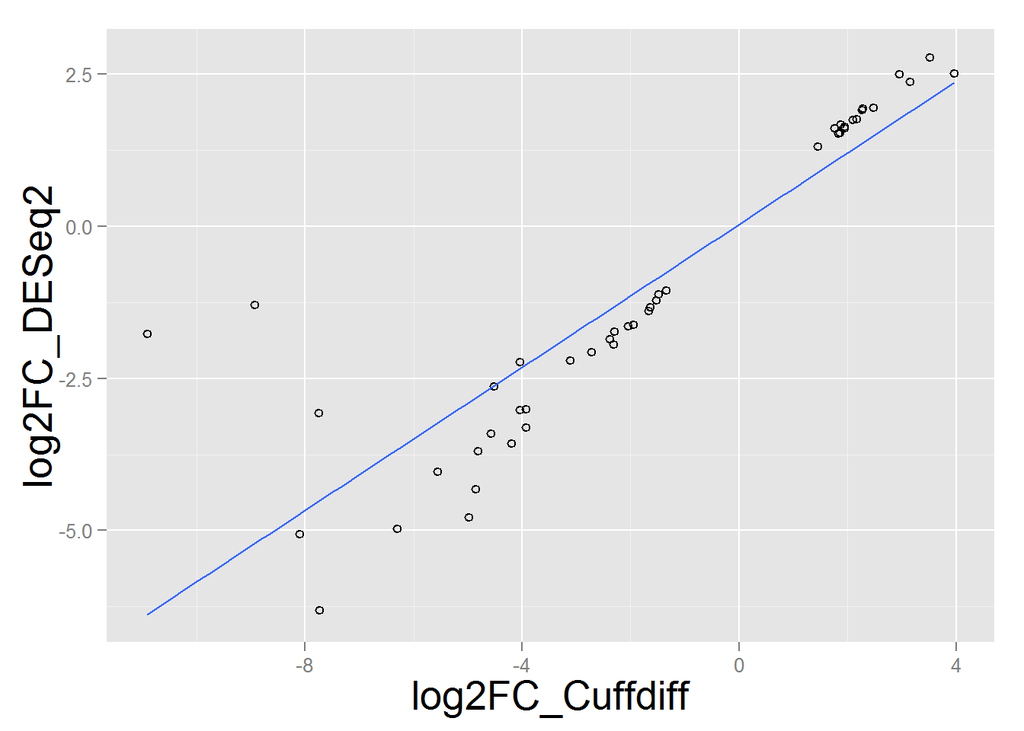

```r
#From the graph as seen in the retina and RCS samples, the P values determined by Cuffdiff were in general higher than those determined DESeq2 in crispr samples.  There was not a strong trend on visual inspection and R2 was small when all the genes (complete cases in both datasets) were accounted for: adjusted R-squared: 0.2796

###Compare fold change values between Cuffdiff and DESeq2 for genes with adjusted p-values < 2 and linear fold change of at least 2.

#convert characters to NA from log2FC_cuffdiff and remove NAs.
Crispr_cuffDes$log2FC_Cuffdiff <- as.numeric(as.character(Crispr_cuffDes$log2FC_Cuffdiff))
Crispr_cuffDes <- Crispr_cuffDes[complete.cases(Crispr_cuffDes),]

#convert infinite values to NA from log2FC_cuffdiff and remove NAs.
is.na(Crispr_cuffDes) <- sapply(Crispr_cuffDes, is.infinite)
Crispr_cuffDes <- Crispr_cuffDes[complete.cases(Crispr_cuffDes),]

#Filter for genes with log2 fold change > 1 using both Cuffdiff and DESeq2
Crispr_cuffDes_FC <- filter(Crispr_cuffDes, abs(log2FC_Cuffdiff) > 1 & abs(log2FC_DESeq2) > 1)

#Filter for genes with log2 fold change > 1 and adjusted p-value < 0.05 using both Cuffdiff and DESeq2
Crispr_cuffDes_FC_Sig <- filter(Crispr_cuffDes_FC, Cuffdiff_adjp < 0.05 & DESeq2_adjp < 0.05)
#45 genes in crispr samples had a log2 fold change of 1 (linear fold change of 2) and an adjusted pvalue of 0.05 in both cuffdiff and Deseq2 in wild versus mutants.

ggplot(data = Crispr_cuffDes_FC_Sig, aes(x = log2FC_Cuffdiff, y = log2FC_DESeq2)) + geom_point(shape = 21) + geom_smooth(method=lm, se=FALSE) + theme(axis.title.x = element_text(size = 20), axis.title.y = element_text(size = 20))
```

```r
cor(Crispr_cuffDes_FC_Sig$log2FC_Cuffdiff, Crispr_cuffDes_FC_Sig$log2FC_DESeq2, use = "complete.obs")
```

```
## [1] 0.8834043
```

```r
#The correlation for log2FC between cuffdiff and DESeq2 was very strong with these genes in Crispr samples.

fit2Crispr <- lm(log2FC_Cuffdiff ~ log2FC_DESeq2, data=Crispr_cuffDes_FC_Sig)
fit2Crispr
```

```
##
## Call:
## lm(formula = log2FC_Cuffdiff ~ log2FC_DESeq2, data = Crispr_cuffDes_FC_Sig)
##
## Coefficients:
##   (Intercept)  log2FC_DESeq2
##       -0.4622         1.3288
```

```r
confint(fit2Crispr)
```

```
##                   2.5 %    97.5 %
## (Intercept)   -1.052074 0.1277248
## log2FC_DESeq2  1.112051 1.5456228
```

```r
summary(fit2Crispr)
```

```
##
## Call:
## lm(formula = log2FC_Cuffdiff ~ log2FC_DESeq2, data = Crispr_cuffDes_FC_Sig)
##
## Residuals:
##     Min      1Q  Median      3Q     Max
## -8.1083  0.1870  0.4226  0.5888  1.8225
##
## Coefficients:
##               Estimate Std. Error t value Pr(>|t|)
## (Intercept)    -0.4622     0.2925   -1.58    0.121
## log2FC_DESeq2   1.3288     0.1075   12.36 9.52e-16 ***
## ---
## Signif. codes:  0 '***' 0.001 '**' 0.01 '*' 0.05 '.' 0.1 ' ' 1
##
## Residual standard error: 1.797 on 43 degrees of freedom
## Multiple R-squared:  0.7804, Adjusted R-squared:  0.7753
## F-statistic: 152.8 on 1 and 43 DF,  p-value: 9.524e-16
```

```r
#adjusted R-squared = 0.7753

#As in the case for retina and RCS, comparing genes from crispr samples that were statistically significant as well as having a fold change > 2 resulted in a stronger correlation and therefore agreement between cuffdiff and DESEq2 than comparing all genes.
```

#### Overlap of DE genes Crispr gene and Retina

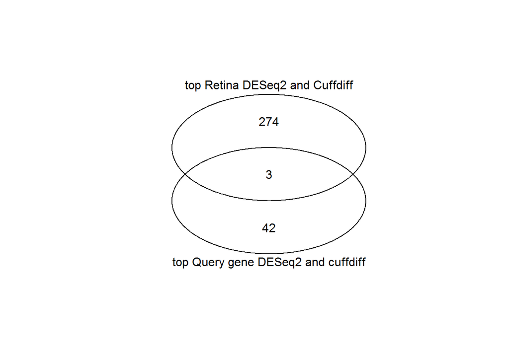

```r
venn(list("top Query gene DESeq2 and cuffdiff" = Crispr_cuffDes_FC_Sig$GeneID, "top Retina DESeq2 and Cuffdiff" = PR_cuffDes_FC_Sig$GeneID))
```

```r
CommonQuery_Retina_CuffDes <- Crispr_cuffDes_FC_Sig[Crispr_cuffDes_FC_Sig$GeneID %in% PR_cuffDes_FC_Sig$GeneID,]
CommonQuery_Retina_CuffDes
```

```
##                GeneID  gene log2FC_Cuffdiff Cuffdiff_adjp log2FC_DESeq2
## 8   ENSG00000101825.7 MXRA5         3.13993     0.0139884      2.369860
## 12 ENSG00000115414.14   FN1         1.75550     0.0139884      1.610511
## 14  ENSG00000117226.7  GBP3         1.85726     0.0139884      1.539020
##    DESeq2_adjp
## 8  0.000000261
## 12 0.000002430
## 14 0.000344401
```

```r
#There were 3 genes that were differentially expressed between crispr gene and Retina in agreement between cuffdiff and DESEq2 methods when adjusted for fold change > 2.
```

#### Overlap of DE genes Crispr genes and RCS

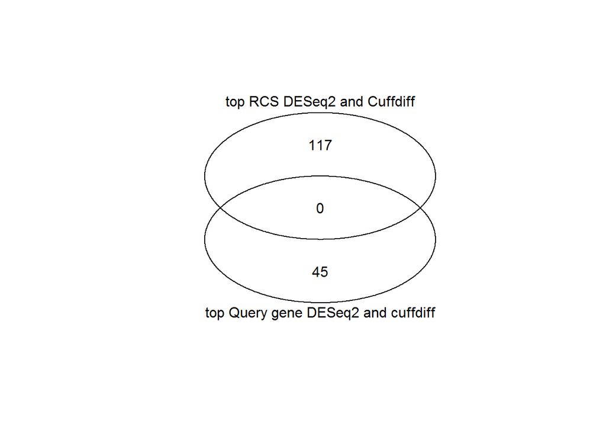

```r
venn(list("top Query gene DESeq2 and cuffdiff" = Crispr_cuffDes_FC_Sig$GeneID, "top RCS DESeq2 and Cuffdiff" = PRCS_cuffDes_FC_Sig$GeneID))
```

```r
CommonQuery_RCS_CuffDes <- Crispr_cuffDes_FC_Sig[Crispr_cuffDes_FC_Sig$GeneID %in% PRCS_cuffDes_FC_Sig$GeneID,]
#There were no genes DE common in crispr gene as well as RCS at the interception of cuffdiff and DESEq2 when adjusted for fold change > 2.
```

## Conclusions

Comparing DESEQ2 and Cuffdiff I found a significant agreement for differentially expressed genes that also had a fold change greater than 2 in retina, RCS and crispr gene knockout of interest. Comparing gene knockout to AMD eyes resulted in three genes in agreement between cuffdiff and deseq2 for differential expression in gene of interest and retina. Based on the function of these genes, our results suggest that our crispr knockout gene might be implicated in cell adhesion and migration, and in cytokine response in immune system. Further studies in underway to validate results with increase in the number of biological replicates and in investigating biological pathways through which knockout gene of interest might be implicated in AMD.